# Solar Energy Project

William Kingwill

16/07/2020

## Introduction

The aim of this project is to creste a statistical or machine learning technique in order to provide a short term prediction of solar production. The prediction will be done over 98 **Oklahoma Mesonet** sites which serve as solar farms. First a exploratory data analysis will be done on the data sets provided. Then a model will be built and predicitons created. The evaluation of the predicitons will be done using the MAE: $MAE = 1/SE \sum_{s}^{S}\sum_{e}^{E} |Fse - Ose|$

## Data Exploratory Analysis

There were 3 data files provided for this project:

### Dimensions

- The dimensions of *solar_dataset* are 6909 x 456
- The dimensions of *stations_info* are 98 x 4
- The dimensions of *additional_variables* are 6909 x 101

As the last 1796 rows of the *solar_dataset* contain Null values in the first 98 columns to make the predicitons over. This was split into the test set *pred_test* and the dataset used for training *train1*.

- The dimensions of *pred_test* are 1796 x 456
- The dimensions of *train1* are 5113 x 456

### Overview plots

To gain a overview of the datasets, the amount of discrete columns, continuous columns, missing coloumns, complete rows and missing observations were plotted.

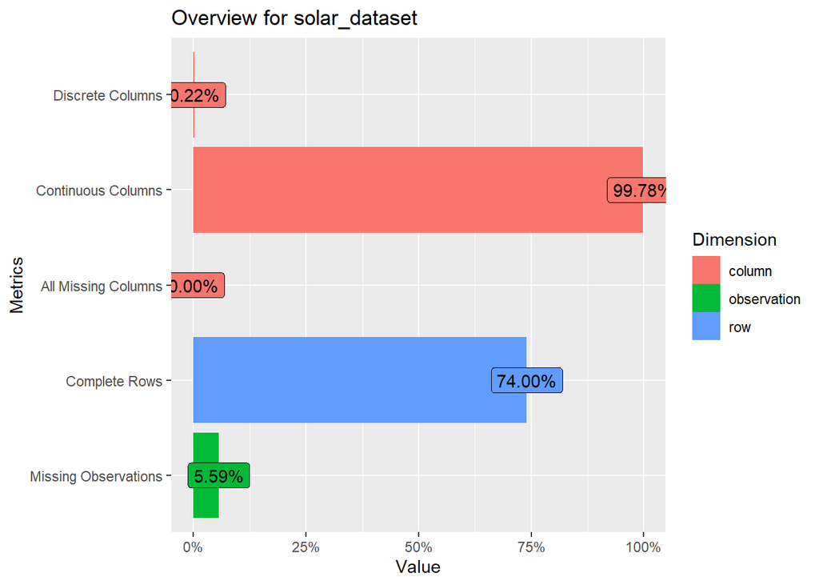

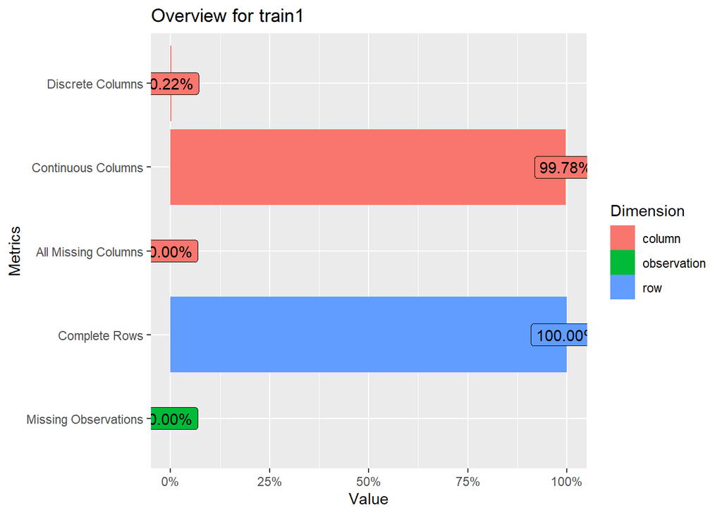

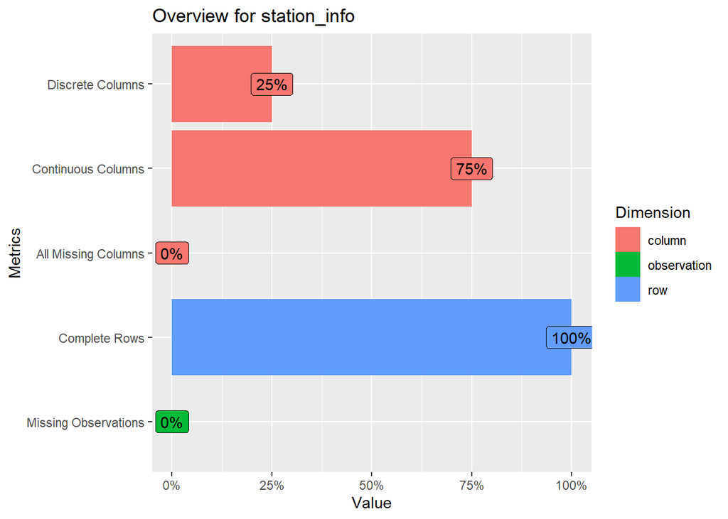

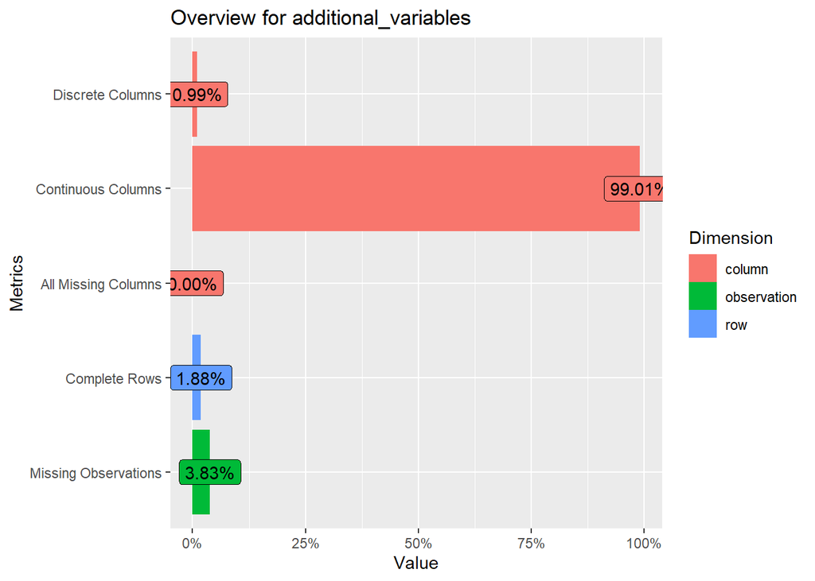

### Column Statistics

The statistics were computed for each column of the *solar_dataset* and the *additional_variables* datasets. Was not nesicary for the *stations_info* dataset.

For the *solar_dataset*, as there are 456 coloumns in the solar_dataset the Stattistics of only a few are shown in this report to get a overview.

Column

|  | ACME | ADAX | ALTU | APAC | ARNE | BEAV | BESS | BIXB | BLAC | BOIS | BOWL | BREC | BRIS | BUFF | BURB | BURN | BUTL | BYAR | CAMA | CENT | CHAN | CHER | CHEY | CHIC | CLAY | CLOU | COOK | COPA | DURA | … |
| --- | --- | --- | --- | --- | --- | --- | --- | --- | --- | --- | --- | --- | --- | --- | --- | --- | --- | --- | --- | --- | --- | --- | --- | --- | --- | --- | --- | --- | --- | --- |
| Min. | 12000 | 510000 | 900 | 3300 | 477300 | 300 | 510600 | 74700 | 36000 | 467100 | 497700 | 268800 | 642600 | 1200 | 32100 | 300 | 101700 | 545700 | 6300 | 1500 | 519000 | 399300 | 55800 | 394500 | 12300 | 502200 | 236700 | 517200 | 542700 | … |
| 1st Qu. | 11404200 | 10611000 | 11674500 | 11637000 | 11666400 | 11493600 | 11712600 | 9794700 | 10485760 | 12463800 | 10642800 | 10917600 | 10269600 | 11364000 | 10251300 | 11229300 | 11541000 | 10841400 | 11665500 | 10378200 | 10412400 | 11154300 | 11889300 | 11244900 | 9643500 | 9425400 | 9730800 | 9872700 | 10763700 | … |
| Median | 16946400 | 16299300 | 17073600 | 17062500 | 17578500 | 17520900 | 17176500 | 15725700 | 15873000 | 18885900 | 16043700 | 16579500 | 15716100 | 17238900 | 15995400 | 16367100 | 17280300 | 16661100 | 17497500 | 16028100 | 15917700 | 17007600 | 17562600 | 16616700 | 15261300 | 15612000 | 15648900 | 15868800 | 16393800 | … |
| Mean | 16877462 | 16237534 | 17119189 | 17010565 | 17560173 | 17612143 | 17304074 | 15969634 | 16061707 | 18688943 | 16034081 | 16655129 | 16014658 | 17304512 | 16104884 | 16438717 | 17331768 | 16597616 | 17515475 | 16055065 | 15993253 | 17015640 | 17484171 | 16541993 | 15486166 | 15656934 | 15667280 | 15896897 | 16348533 | … |
| 3rd Qu. | 23734800 | 23027400 | 23903700 | 23909400 | 24503700 | 24683100 | 24241200 | 22940400 | 22938300 | 25364100 | 22818900 | 23529900 | 22897200 | 24264000 | 23184600 | 23201400 | 24228900 | 23521800 | 24429600 | 22875300 | 22689600 | 23939400 | 24456000 | 23201100 | 22236000 | 22310400 | 22494600 | 22858500 | 23079900 | … |
| Max. | 31347900 | 31227000 | 31411500 | 31616100 | 32645700 | 32884800 | 31887900 | 31702200 | 30771900 | 32922000 | 30781200 | 31686300 | 31034400 | 32508900 | 30988500 | 30654600 | 32085600 | 32630700 | 32383500 | 31320000 | 30746700 | 33131700 | 31696200 | 30572400 | 30585000 | 31603500 | 31453500 | 31713600 | 31234200 | … |

The *additional_variables* statistical summary is shown:

|  | V6409 | V3529 | V649 | V7129 | V2089 | V1369 | V4969 | V5689 | V7849 | V2809 | V4970 | V650 | V7130 | V2810 | V4249 | V5690 | V3530 | V6410 | V2090 | V7850 | V360 | V4250 | V1801 | V1370 | V361 | V1800 | V3961 | V4680 | V3240 | … |
| --- | --- | --- | --- | --- | --- | --- | --- | --- | --- | --- | --- | --- | --- | --- | --- | --- | --- | --- | --- | --- | --- | --- | --- | --- | --- | --- | --- | --- | --- | --- |
| Min. | 0.0000000 | 0.0000000 | 0.0000000 | 0.0000000 | 0.0000000 | 0.0000000 | 0.0000000 | 0.00000 | 0.0000000 | 0.0000000 | 0.0000000 | 0.0000000 | 0.0000000 | 0.0000000 | 0.0000000 | 0.0000000 | 0.0000000 | 0.0000000 | 0.0000000 | 0.0000000 | 0.0000000 | 0.0000000 | 0.0000000 | 0.0000000 | 0.0000000 | 0.0000000 | 0.0000000 | 0.0000000 | 0.0000000 | … |
| 1st Qu. | 0.0000000 | 0.0000000 | 0.0000000 | 0.0000000 | 0.0000000 | 0.0000000 | 0.0000000 | 0.00000 | 0.0000000 | 0.0000000 | 0.0000000 | 0.0000000 | 0.0000000 | 0.0000000 | 0.0000000 | 0.0000000 | 0.0000000 | 0.0000000 | 0.0000000 | 0.0000000 | 0.0000000 | 0.0000000 | 0.0000000 | 0.0000000 | 0.0000000 | 0.0000000 | 0.0000000 | 0.0000000 | 0.0000000 | … |
| Median | 0.0000000 | 0.0000000 | 0.0000000 | 0.0000000 | 0.0000000 | 0.0000000 | 0.0000000 | 0.00000 | 0.0000000 | 0.0000000 | 0.0000000 | 0.0000000 | 0.0000000 | 0.0000000 | 0.0000000 | 0.0000000 | 0.0000000 | 0.0000000 | 0.0000000 | 0.0000000 | 0.0000000 | 0.0000000 | 0.0000000 | 0.0000000 | 0.0000000 | 0.0000000 | 0.0000000 | 0.0000000 | 0.0000000 | … |
| Mean | 0.4905402 | 0.4891172 | 0.4966667 | 0.4925403 | 0.5004828 | 0.5077472 | 0.4995573 | 0.49015 | 0.4956363 | 0.5173144 | 0.5419358 | 0.5174659 | 0.5404688 | 0.5280323 | 0.4884263 | 0.5079298 | 0.5226354 | 0.5381891 | 0.5132686 | 0.5308908 | 0.4079355 | 0.5461263 | 0.4782921 | 0.5219737 | 0.4884698 | 0.4211688 | 0.4755373 | 0.4108382 | 0.4126189 | … |
| 3rd Qu. | 0.0100000 | 0.0100000 | 0.0100000 | 0.0100000 | 0.0000000 | 0.0100000 | 0.0100000 | 0.01000 | 0.0000000 | 0.0100000 | 0.0400000 | 0.0300000 | 0.0400000 | 0.0400000 | 0.0100000 | 0.0300000 | 0.0300000 | 0.0400000 | 0.0400000 | 0.0300000 | 0.0200000 | 0.0400000 | 0.0400000 | 0.0400000 | 0.0500000 | 0.0200000 | 0.0500000 | 0.0200000 | 0.0200000 | … |
| Max. | 40.2999992 | 51.4099998 | 53.9900017 | 51.3800011 | 45.0999985 | 47.4599991 | 53.8699989 | 39.79000 | 47.2200012 | 53.4700012 | 49.6800003 | 46.2000008 | 37.2000008 | 36.8100014 | 59.2200012 | 42.4000015 | 41.6199989 | 52.3899994 | 45.7999992 | 43.0999985 | 33.7999992 | 53.5099983 | 44.9799995 | 41.8499985 | 41.7000008 | 38.6500015 | 38.0000000 | 39.7400017 | 38.4000015 | … |
| NA’s | 430.0000000 | 33.0000000 | 138.0000000 | 457.0000000 | 198.0000000 | 11.0000000 | 268.0000000 | 443.00000 | 135.0000000 | 337.0000000 | 302.0000000 | 465.0000000 | 41.0000000 | 470.0000000 | 364.0000000 | 388.0000000 | 189.0000000 | 426.0000000 | 472.0000000 | 353.0000000 | 278.0000000 | 37.0000000 | 70.0000000 | 439.0000000 | 426.0000000 | 47.0000000 | 88.0000000 | 228.0000000 | 349.0000000 | … |

### Distributions

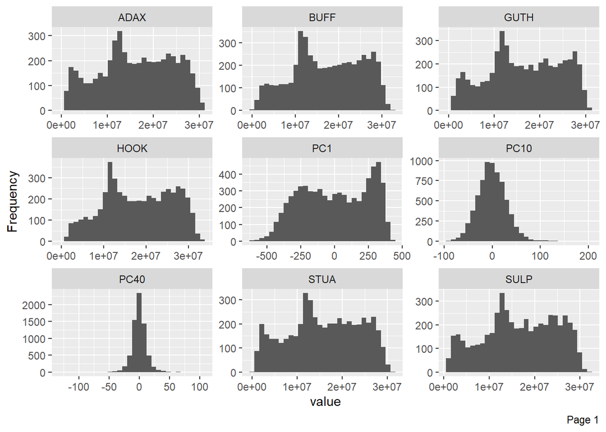

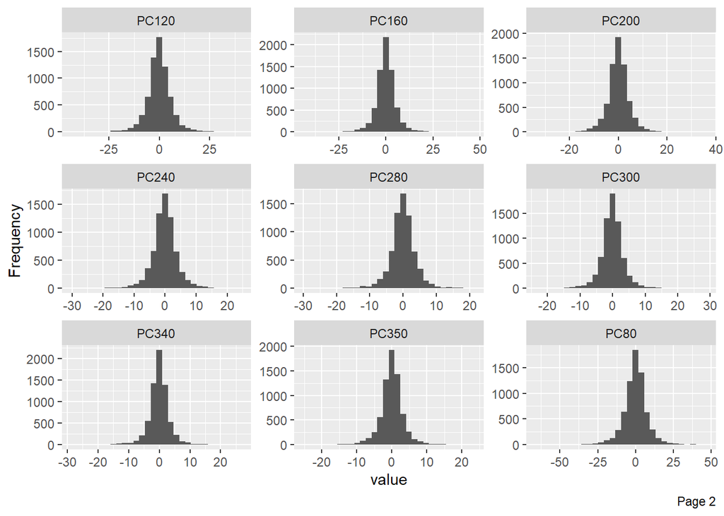

### Box Plots

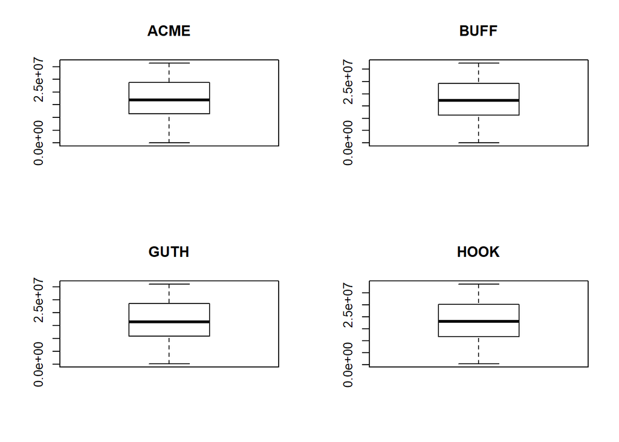

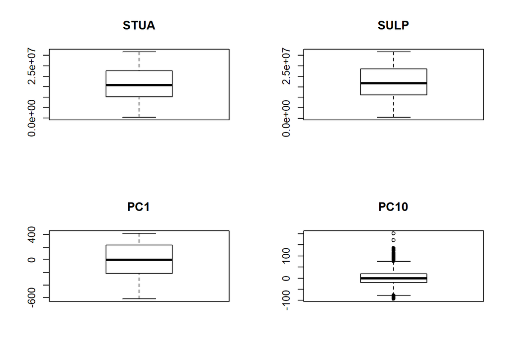

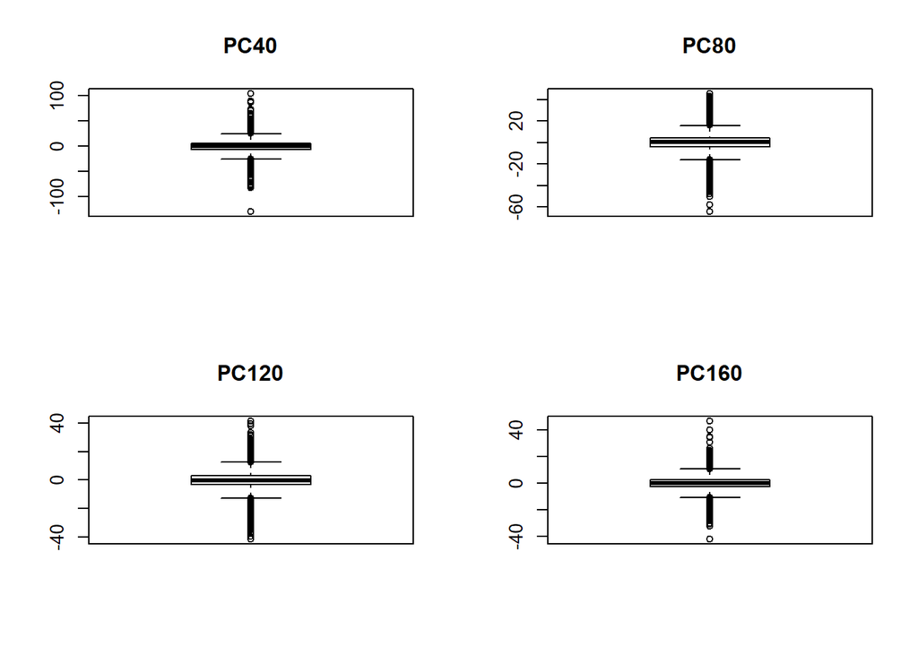

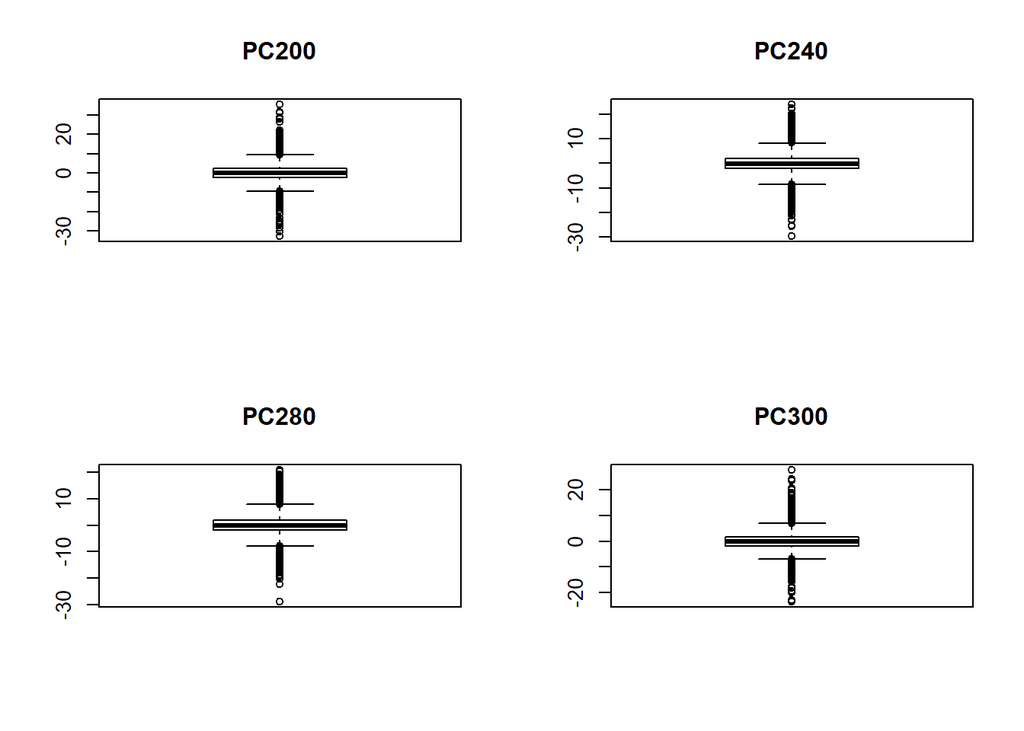

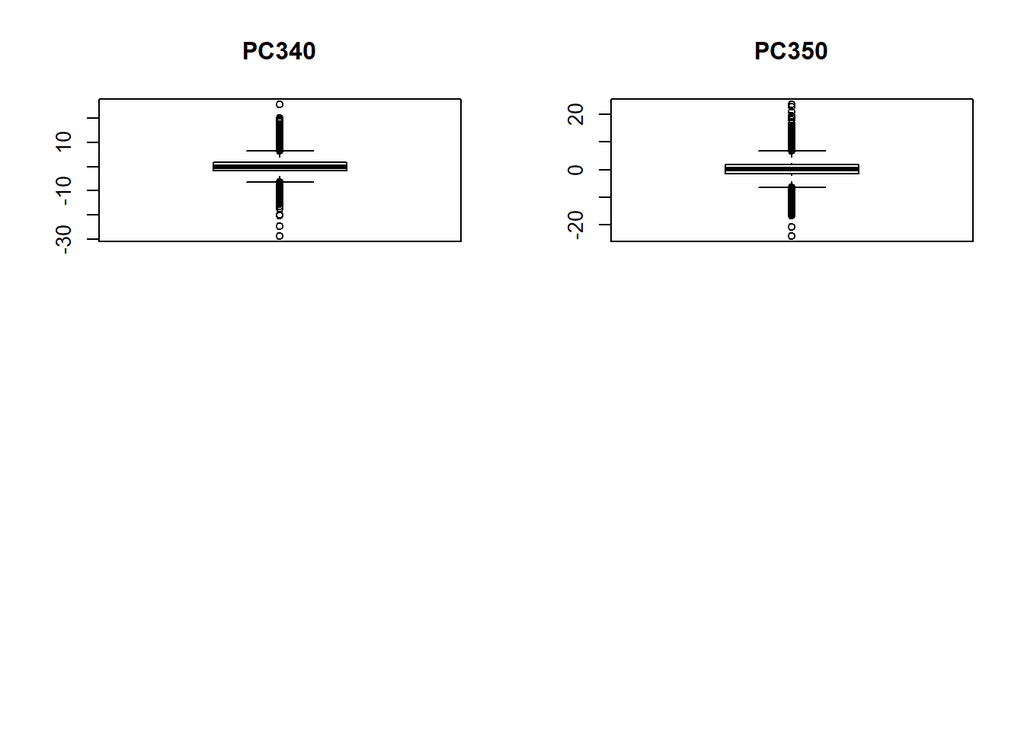

### Average Solar Production

It may be interesting to see the average solar production over time. As expected one can clearly see that the solar production foloows a seasonal profile.

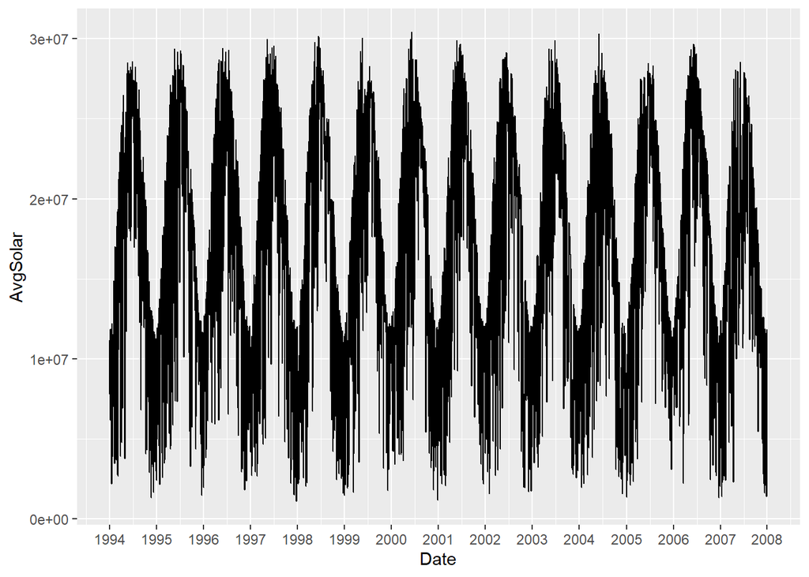

### NULL Values

From the overview plots it is seen that *solar_dataset* and *additional_variables* contain null values. The null values in *solar_dataset* are the values that need to be predicted so can be ignored. The null values in *additional_variables* needs to be explored further.

The total Null values in each column are calculated:

Null values for additional_variables

|  | No. Null Values |
| --- | --- |
| Date | 0 |
| V6409 | 430 |
| V3529 | 33 |
| V649 | 138 |
| V7129 | 457 |
| V2089 | 198 |
| V1369 | 11 |
| V4969 | 268 |
| V5689 | 443 |
| V7849 | 135 |
| V2809 | 337 |
| V4970 | 302 |
| V650 | 465 |
| V7130 | 41 |
| V2810 | 470 |
| V4249 | 364 |
| V5690 | 388 |
| V3530 | 189 |
| V6410 | 426 |
| V2090 | 472 |
| V7850 | 353 |
| V360 | 278 |
| V4250 | 37 |
| V1801 | 70 |
| V1370 | 439 |
| V361 | 426 |
| V1800 | 47 |
| V3961 | 88 |
| V4680 | 228 |
| V3240 | 349 |

[output cut: 71 more lines]

It is clear that many null values in the additional variables table. The percentage of nulls in each variable is calculated to see if any columns need to be discarderd. No variables are found to have large percentage nulls so no coloumns are discarded.

Percentage Null values for additional_variables

|  | x |
| --- | --- |
| Date | 0.0000000 |
| V6409 | 6.2237661 |
| V3529 | 0.4776379 |
| V649 | 1.9973947 |
| V7129 | 6.6145607 |
| V2089 | 2.8658272 |
| V1369 | 0.1592126 |
| V4969 | 3.8789984 |
| V5689 | 6.4119265 |
| V7849 | 1.9539731 |
| V2809 | 4.8776958 |
| V4970 | 4.3711101 |
| V650 | 6.7303517 |
| V7130 | 0.5934289 |
| V2810 | 6.8027211 |
| V4249 | 5.2684904 |
| V5690 | 5.6158634 |
| V3530 | 2.7355623 |
| V6410 | 6.1658706 |
| V2090 | 6.8316688 |
| V7850 | 5.1092778 |
| V360 | 4.0237372 |
| V4250 | 0.5355334 |
| V1801 | 1.0131712 |
| V1370 | 6.3540310 |
| V361 | 6.1658706 |
| V1800 | 0.6802721 |
| V3961 | 1.2737010 |
| V4680 | 3.3000434 |
| V3240 | 5.0513823 |

[output cut: 71 more lines]

To handle the Null values, the mean is used to be inputed as per the following code:

```r
###Fill missing values with mean
fill_missing_values <- function(x){
  if (class(x) == "numeric" ){
    x[is.na(x)] <- mean(x, na.rm = TRUE); # Replace with mean
  } else {

  }
  return(x);
}

additional_variables <- data.frame(sapply(additional_variables, fill_missing_values));
```

From the ovewiew we can see all null values have been handled:

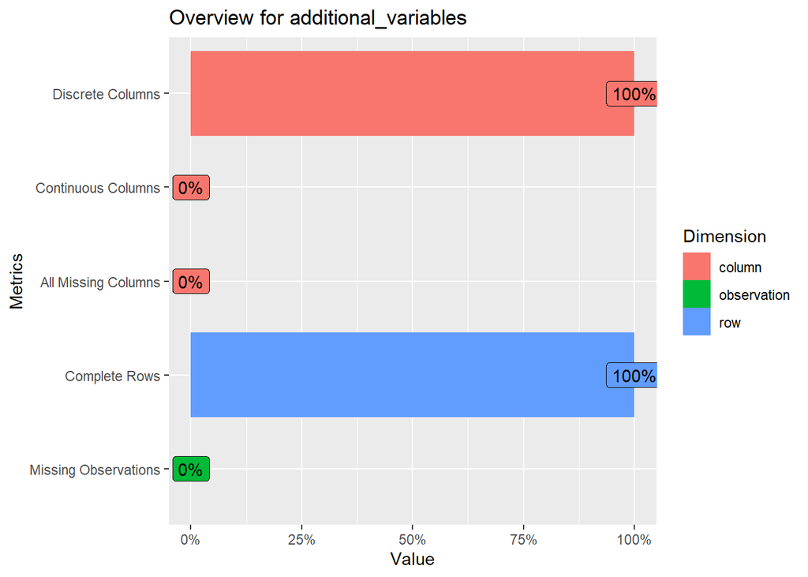

### Map of **Oklahoma Mesonet** sites

To explore the data of *stations_info* a interactive map of the locations of all the 98 different weather stations was created.

[interactive chart not shown]

## Feature extraction

In order to help with the forcasting it was decided to extract features from the dates: DayofYear and MonthofYear. As shown in the following code:

```r
###Extract features from Dates, dayofyear, monthofyear
solar_dataset_pred <- as.data.frame(solar_dataset)
solar_dataset_pred$Date <- as.Date(solar_dataset_pred$Date, format = "%Y%m%d")
solar_dataset_pred<- mutate(solar_dataset_pred, DayofYear = yday(solar_dataset_pred$Date))
solar_dataset_pred <- mutate(solar_dataset_pred, MonthofYear = month(solar_dataset_pred$Date))
```

## Conclusion

A full data analysis was conducted to get a good general overview of the data. Null values were delt with. No outlier handling, dimensionality reduction or data scaling were needed for the model. As PCA had already been done on the variables included no correlation testing was deemed nessicary for this report